# Police Resourcing

Start by importing the offense data from Tim’s Excel workbook. To help with visualising the data we need to pivot to narrow format, fix up the dates, and tidy up the columns a bit.

```r
library(dplyr)
library(tidyr)
library(readxl)
library(lubridate)
offence_by_month <-
  read_excel("~/Desktop/Tim/RCI_offencebymonth.xlsm") %>%
  gather(key = "Date", value = "Count", -LGA, -`Offence category`, -Subcategory) %>%
  mutate(Date = as.Date(as.numeric(Date), origin = "1900-01-01")) %>%
  mutate(Date = make_date(year(Date), month(Date))) %>% # Making sure dates are 1st of month
  rename(Offence = `Offence category`) %>%
  select(LGA, Date, Offence, Subcategory, Count)
```

We can now plot the number of offences per month over time for the 5 LGAs we’re interested in, plus Wollongong (mainly because it makes the plot look better to have 6 instead of 5).

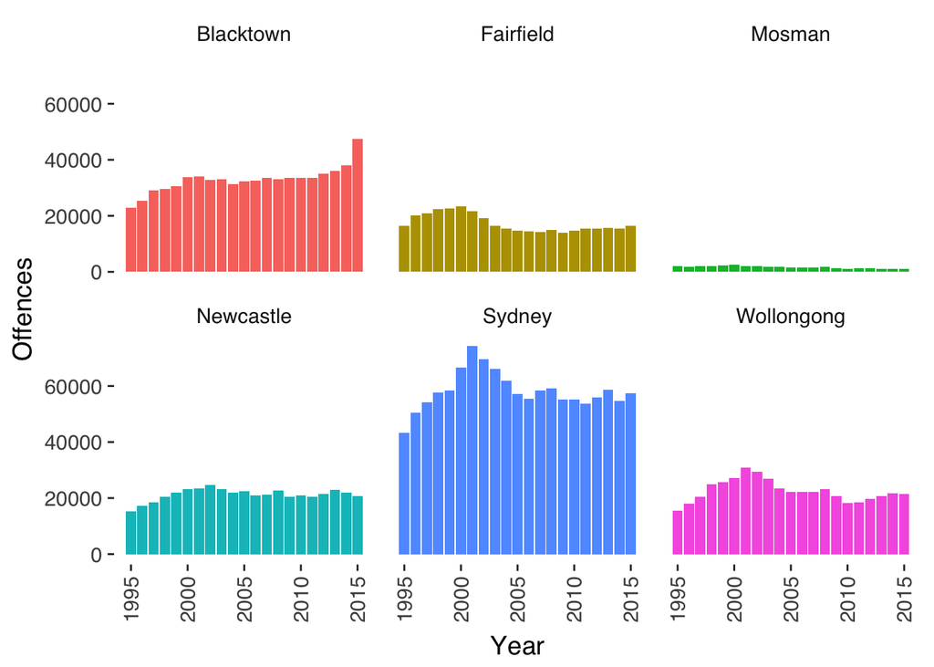

```r
library(ggplot2)
library(ggthemes)
offence_by_month %>%
  filter(LGA %in% c("Sydney", "Blacktown", "Newcastle", "Fairfield", "Mosman", "Wollongong")) %>%
  ggplot(aes(x=year(Date), weight=Count, fill=LGA)) +
    geom_bar() +
    facet_wrap(~LGA) +
    xlab("Year") + ylab("Offences") +
    theme_tufte(base_size = 14, base_family = "sans") +
    theme(axis.text.x = element_text(angle = 90, hjust = 1, vjust = 0.5), legend.position = "none")
```

So that all works. Cool.

Now we need to go and get the police strength (staffing) figures. The datasets are a bit of a mess, with a mix of HTML pages and PDFs, and with a constantly changing web address. I’ve manually worked through all of these issues and kept everything in an Excel sheet to make it a bit easier to manage.

This takes a few minutes to run.

```r
library(rvest)
library(stringr)
library(readr)
library(lubridate)
library(pdftools)

# This is a very messy set of data with a constantly changing format. The script
# below works at the moment, but it's not pretty, and there are still a few
# niggling issues. But it's good enough for now!

controls <- read_excel("~/code/police/scraping_controls.xlsx", na = "NA")
controls <- controls[!is.na(controls$URL),]

monthly_data <- vector(mode = "list", length = nrow(controls))

for (i in 1:nrow(controls)) {

  month_name <- format(make_date(month=controls$Month[i]), "%B")
  year <- controls$Year[i]
  message("Extracting data for ", month_name, " ", year)

  if (controls$Format[i] == "html") {
    dat <-
      html(controls$URL[i]) %>%
      html_node("#content-main div") %>%
      html_text() %>%
      str_replace_all("\r\n\r\n", "|") %>%
      str_replace_all("\r\n", "\n") %>%
      read_delim(delim = "|")
    names(dat) <- c("REGION", "LAC", "AUTH", "ACTUALS")
    keep_up_to <- which(str_detect(dat$REGION, "Command"))[1] - 1
    # Drop first row and all crud at the end, also drop first column
    dat <- dat[2:keep_up_to,-1]
    # Drop totals
    total_rows <- which(str_detect(dat$LAC, "Total") | str_detect(dat$LAC, "^\\s*$"))
    dat <- dat[-total_rows,]
    dat$DATE <- make_date(controls$Year[i], controls$Month[i])
    dat$LAC <- str_replace(dat$LAC, "^ *", "")
    monthly_data[[i]] <- dat

  } else if (controls$Format[i] == "pdf") {

    dat <- pdf_text(controls$URL[i])[1] %>% str_split("\n")
    header_row <- which(str_detect(dat[[1]], "Region.*Auth.*Actual"))
    dat <- dat[[1]][-c(1:header_row)]
    dat <- dat[-which(dat == "" | str_detect(dat, "Use Only"))]
    total_rows <- which(str_detect(dat, "Total"))
    dat <- dat[-total_rows]
    dat <- str_split(dat, "  +")
    dat <- as.data.frame(t(data.frame(dat)))
    row.names(dat) <- 1:nrow(dat)
    names(dat) <- c("REGION", "LAC", "AUTH", "ACTUALS")
    dat$DATE <- make_date(controls$Year[i], controls$Month[i])
    dat$LAC <- str_replace(dat$LAC, "^ *", "")
    monthly_data[[i]] <- dat[,-1]

  }
}
police_strength <- do.call("rbind", monthly_data)
police_strength$AUTH <- as.numeric(police_strength$AUTH)
police_strength$ACTUALS <- as.numeric(police_strength$ACTUALS)
police_strength <- police_strength[!is.na(police_strength$LAC),]
police_strength[police_strength$LAC == "Central Metropolitan","LAC"] <- "Central Metro"
police_strength[str_detect(police_strength$LAC, "Sydney City"),"LAC"] <- "Sydney City"
```

With all of the data collected, we now need to filter and process so it’s ready for plotting. This requires a bunch of data cleaning, then a filter and a pivot, followed by the creation of some new columns for the LGA staffing levels (based on the formula given by Tim). We also need to manually insert the value for Fairfield LGA for July 2013, as it somehow got missed and it’s quicker to fix manually than it is to fix the import process.

```r
# Fixing most of the NAs
missing_rows <- which(is.na(police_strength$ACTUALS))
police_strength$ACTUALS[missing_rows] <- 0

library(tidyr)
police_strength_LGA <-
police_strength %>%
  # Fixing some data quality issues with LAC names
  mutate(LAC = str_replace(LAC, "(Quakers Hill.*)", "Quakers Hill")) %>%
  mutate(LAC = str_replace(LAC, "Bktown", "Blacktown")) %>%
  # Fixing a name change
  mutate(LAC = str_replace(LAC, "City Central", "Sydney City")) %>%
  # Filter for just the stations we care about
  filter(LAC %in% c("Sydney City", "Central Metro", "City Central",
                    "Kings Cross", "Redfern", "Leichhardt", "Surry Hills",
                    "Blacktown", "Quakers Hill", "Mt Druitt", "Newcastle City",
                    "Fairfield", "Harbourside")) %>%
  # Pivot into a wide table
  select(-AUTH) %>%
  spread(LAC, ACTUALS) %>%
  # Calulate LGA staffing using Tim's formula
  mutate(SydneyLGA =
           `Sydney City` +
           `Central Metro` +
           `Kings Cross` +
           `Redfern` +
           `Surry Hills` +
           (`Leichhardt`/2),
         BlacktownLGA =
           `Blacktown` +
           `Quakers Hill` +
           `Mt Druitt`,
         NewcastleLGA =
           `Newcastle City`,
         FairfieldLGA =
           `Fairfield`,
         MosmanLGA =
           (`Harbourside`/2)) %>%
  # Select just the LGAs (remove all of the LACs)
  select(DATE, SydneyLGA, BlacktownLGA, NewcastleLGA, FairfieldLGA, MosmanLGA)

  # Somehow lost a single value for Fairfield, so inserting it manually
  fix_row <- which(police_strength_LGA$DATE == "2013-07-01")
  police_strength_LGA[fix_row, "FairfieldLGA"] <- 169
```

Cool. Now we can plot how each LGA’s staffing changed over time.

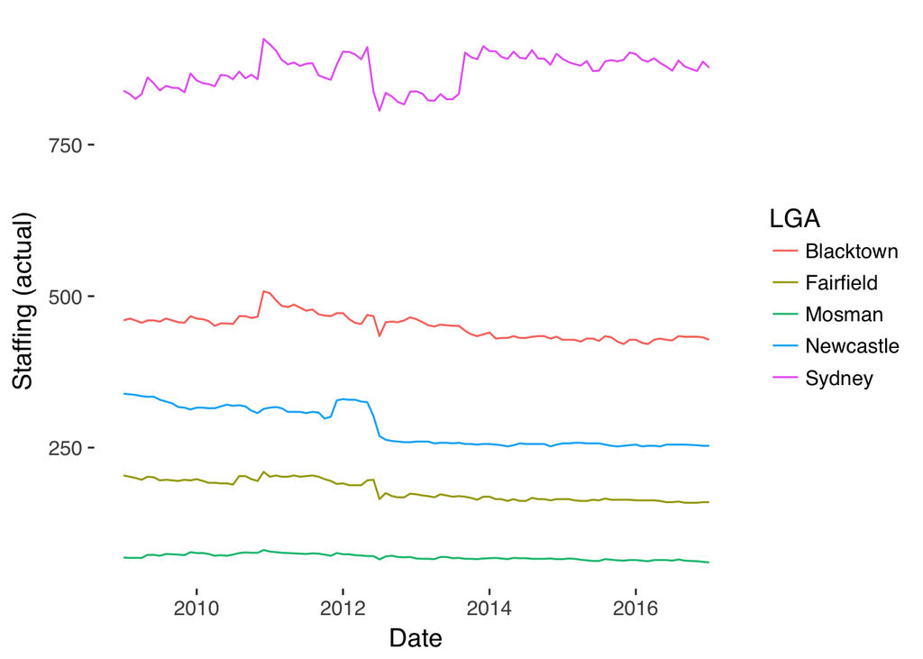

```r
police_strength_LGA %>%
  # Pivoting back to narrow for plotting
  gather("LGA", "Staff", -DATE) %>%
  # Making things look nicer
  mutate(LGA = str_replace(LGA, "LGA", "")) %>%
  # Plotting
  ggplot(aes(x = DATE, y = Staff, col = LGA)) +
    geom_line() +
    labs(x = "Date", y = "Staffing (actual)") +
    theme_tufte(base_size = 14, base_family = "sans")
```

At this point, we have enough data to try some modelling approaches, however the assumptions for these approaches are going to be difficult to determine, so we can stick to visualisation for now, to see if we can identify if there are any clear stories here.

The code below creates a function which will let us plot each of the LGAs easily.

```r
library(gtable)
library(grid)

plot_lga <- function(lga_filter) {

  gg1 <-
  police_strength_LGA %>%
  # Pivoting back to narrow for plotting
  gather("LGA", "Staff", -DATE) %>%
  # Making things look nicer
  mutate(LGA = str_replace(LGA, "LGA", "")) %>%
  # Filtering for specified lGA only
  filter(LGA == lga_filter) %>%
  # Plotting
  filter(DATE >= ymd("2009-01-01")) %>%
  filter(DATE <= ymd("2015-12-31")) %>%
  ggplot(aes(x = DATE, y = Staff)) +
    geom_line(col = "blue") +
    labs(x = "", y = "Police Strength", subtitle = lga_filter, title = "Police staffing and number of offences per month") +
    #theme_tufte(base_size = 14, base_family = "sans") +
    theme(axis.text.x = element_text(angle = 90, hjust = 1, vjust = 0.5), legend.position = "none") +
    scale_x_date(limits=c(ymd("2009-01-01"), ymd("2015-12-31")), date_breaks = "years", labels = NULL)

gg2 <-
  offence_by_month %>%
  filter(LGA == lga_filter) %>%
  filter(Date >= "2009-01-01") %>%
  filter(Date <= "2015-12-31") %>%
  group_by(Date, LGA) %>%
  summarise(Count = sum(Count)) %>%
  ggplot() +
  geom_line(aes(x=Date, y=Count), col="red") +
    #theme_tufte(base_size = 14, base_family = "sans") +
    theme(axis.text.x = element_text(angle = 90, hjust = 1, vjust = 0.5), legend.position = "none") +
    scale_x_date(limits=c(ymd("2009-01-01"), ymd("2015-12-31")), date_breaks = "years", date_labels = "%b %Y") +
    labs(x = "Date", y = "Offences")

## convert plots to gtable objects
g1 <- ggplotGrob(gg1)
g2 <- ggplotGrob(gg2)
g <- rbind(g1, g2, size="first") # stack the two plots
g$widths <- unit.pmax(g1$widths, g2$widths) # use the largest widths
grid.newpage()
grid.draw(g)
}
```

Now to generate some plots…

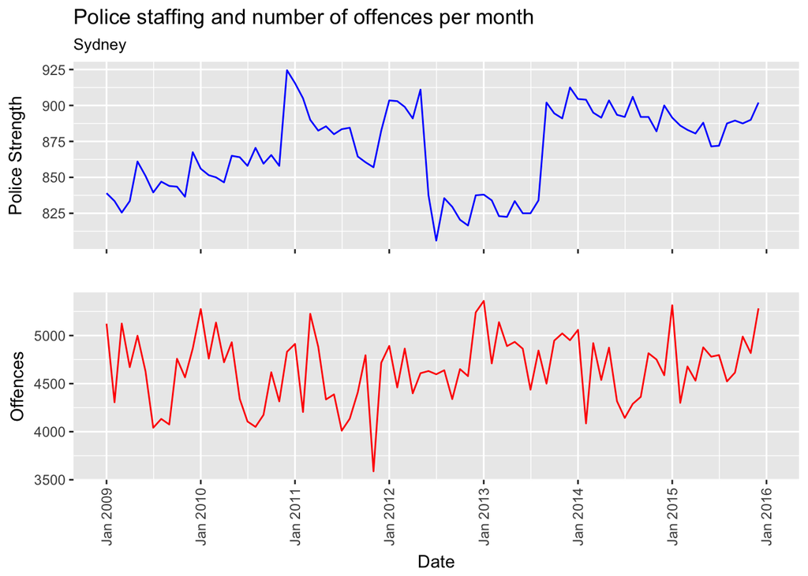

```r
plot_lga("Sydney")
```

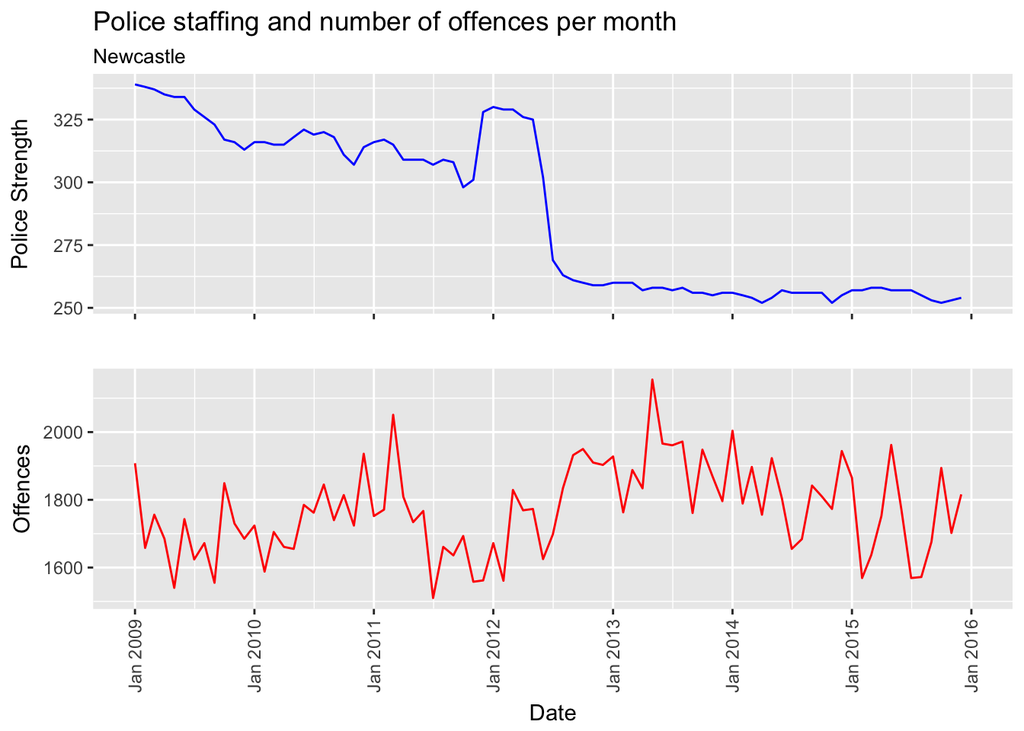

```r
plot_lga("Newcastle")
```

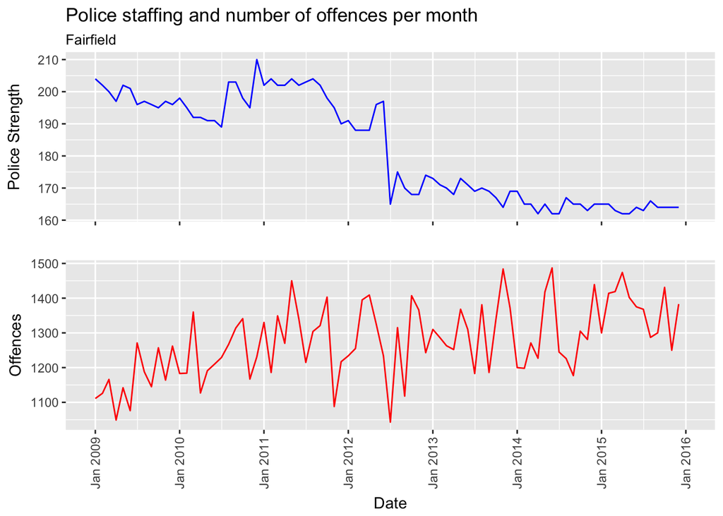

```r
plot_lga("Fairfield")
```

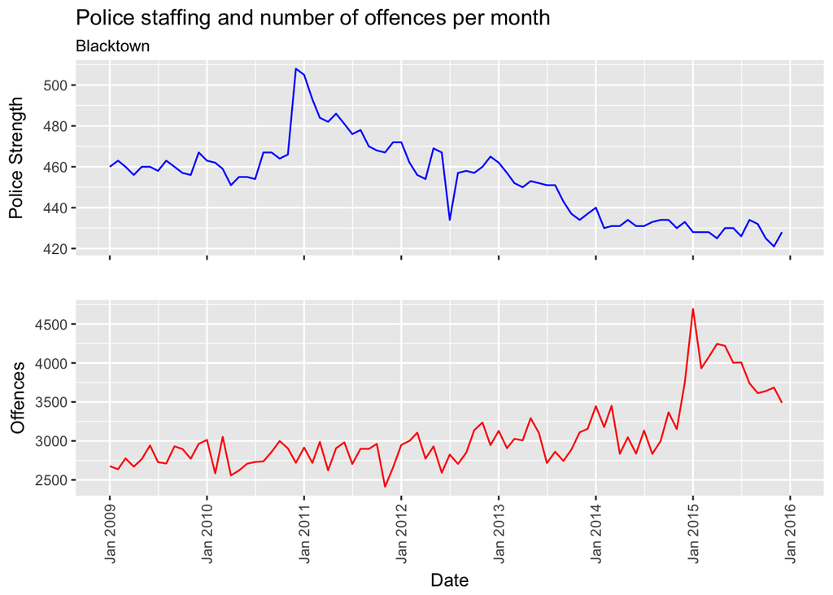

```r
plot_lga("Blacktown")
```

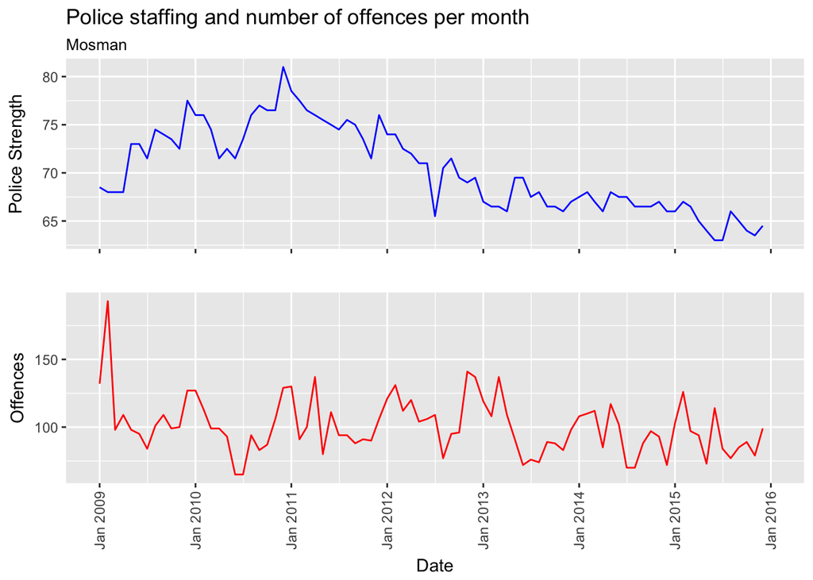

```r
plot_lga("Mosman")
```

One thing we can do to drill down further on this is to filter out non-violent crimes. To do this, we’re going to need a list of such crimes. Once we have a list, it is pretty straight forward to reproduce the above plots with the crimes filtered out.

```r
unique(paste(offence_by_month$Offence, offence_by_month$Subcategory, sep = "-"))
```

```
##  [1] "Homicide-Murder (a)"
##  [2] "Homicide-Attempted murder"
##  [3] "Homicide-Murder accessory, conspiracy"
##  [4] "Homicide-Manslaughter (a)"
##  [5] "Assault-Domestic violence related assault"
##  [6] "Assault-Non-domestic violence related assault"
##  [7] "Assault-Assault Police"
##  [8] "Sexual offences-Sexual assault"
##  [9] "Sexual offences-Indecent assault, act of indecency and other sexual offences"
## [10] "Abduction and kidnapping-NA"
## [11] "Robbery-Robbery without a weapon"
## [12] "Robbery-Robbery with a firearm"
## [13] "Robbery-Robbery with a weapon not a firearm"
## [14] "Blackmail and extortion-NA"
## [15] "Harassment, threatening behaviour and private nuisance-NA"
```

[output cut: 47 more lines]